[figure not shown]

# TOEPASSING SPREIDINGSDIAGRAM - REGRESSIE

## ARMOEDE WERELDBEVOLKING - OEFENING

In deze notebook zal je een regressielijn bepalen bij de data m.b.t. het armoedepercentage binnen de wereldbevolking.

De armoedegrens is vastgelegd op $1,90 per dag per persoon. De Wereldbank verzamelt cijfers om het percentage van de wereldbevolking dat onder de armoedegrens leeft, te monitoren en onderzoek te doen naar de omvang en de oorzaken van die armoede.

### Nodige modules importeren

```python
import numpy as np
import matplotlib.pyplot as plt
import pandas as pd

from scipy.optimize import curve_fit
```

## 1. Data inlezen en visualiseren

Je leest een csv-file in die het percentage van de wereldbevolking dat onder de armoedegrens leeft, bevat over enkele decennia heen [1]. Je zal deze data visualiseren.  
Het bestand vind je in de map `data`: `armoedecijferswereldbank.csv`.

### Opgave

Lees het bestand in en laat de puntenwolk zien.

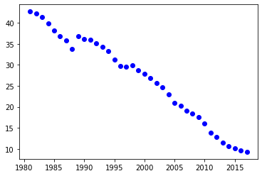

```python
def _rechte(x, a, b):
    return a * x + b


def _linreg(x, y):
    popt, pcov = curve_fit(_rechte, x, y)

    a, b = popt
    return a, b


csv = pd.read_csv('data/armoedecijferswereldbank.csv')

x = np.array(csv['jaar'])
y = np.array(csv['armoedepercentage'])

a, b = _linreg(x, y)

plt.scatter(x, y, color="blue")
plt.show()
```

## 2. Lineaire regressie en grafische voorstelling

### Opdracht

Stel een Python-script op dat bij uitvoer de regressielijn toont die past bij het spreidingsdiagram.

```python
samenhang = np.corrcoef(x[:-1], y[:-1])[0, 1]

print(f"Samenhang {samenhang}")
print(f"Feitelijke waarde {y[-1]}", f"\nTrendlijn waarde {_rechte(2020, a, b)}")
```

```
Samenhang -0.9882986736853263
Feitelijke waarde 9.3
Trendlijn waarde 6.815647382843281
```

## 3. Vergelijking van de regressielijn

### Opdracht

- Stel een Python-script op om de vergelijking van de regressielijn te bepalen.
- Voer het script uit.

### Referentielijst

[1] Poverty headcount ratio at $1.90 a day (2011 PPP) (% of population). https://data.worldbank.org/topic/11

Notebook Python in wiskunde, zie Computationeel denken - Programmeren in Python van [AI Op School](http://www.aiopschool.be), van F. wyffels & N. Gesquière, in licentie gegeven volgens een [Creative Commons Naamsvermelding-NietCommercieel-GelijkDelen 4.0 Internationaal-licentie](http://creativecommons.org/licenses/by-nc-sa/4.0/).